# Regression Notebook

- In our Train data, Random relation between ‘x’ and ‘y’ is given. Based on that analysis ,We have to find the corrosponding ‘y’ for given ‘x’ in test-data.We can use linear regression to find a relation between ‘x’ and ‘y’ based on that relation, we can predict our ans.
- So let’s Start, with importing library , which will be used later…

```r
library(ggplot2)
```

- Now, It’s time to call data here, so import that too…

```r
trainSet = read.csv('/home/kunal/Documents/DS/Linear-Regression/Data/train.csv')
head(trainSet)
```

|  | x | y |
| --- | --- | --- |
| 1 | 2477 | 21.54945 |
| 2 | 5000 | 47.46446 |
| 3 | 15 | 17.21866 |
| 4 | 38 | 36.58640 |
| 5 | 87 | 87.28898 |
| 6 | 36 | 32.46387 |

- So now, we have data. let’s check out for missing value in given training data. Because , missing data is of no use for us.

```r
numberOfNA = length(which(is.na(trainSet)==T))
if(numberOfNA > 0) {
  cat('Oh shit...!!! Missing values found: ', numberOfNA)
  cat('\nRemoving missing values...')
  trainSet = trainSet[complete.cases(trainSet), ]
}
```

```
Oh shit...!!! Missing values found:  1
Removing missing values...
```

- Ok, Data is complete now, no missing… ok Good!!!
- Now, let me check for outlier…
- Okey, Actually Outliers are the value that is far distant from other neighbour suppose, we have data for age: 12,11,14,13,12,123,10 So, in above eg. certainly we have age value 123, i.e. Outlier. It may be some error during data collection.

[figure not shown]

```r
# Divide the graph area in 2 columns
par(mfrow = c(1, 2))
# Boxplot for X
boxplot(trainSet$x, main='X', sub=paste('Outliers: ', boxplot.stats(trainingSet$x)$out))
# Boxplot for Y
boxplot(trainSet$y, main='Y', sub=paste('Outliers: ', boxplot.stats(trainingSet$y)$out))
```

- We can clearly see that we have Two outlier in ‘x’ coloumn. So we need to remove it. So let’s create a function for that.

```r
#Function To remove Outlier
outlierKD <- function(dt, var) {
     var_name <- eval(substitute(var),eval(dt))
     na1 <- sum(is.na(var_name))
     m1 <- mean(var_name, na.rm = T)
     par(mfrow=c(2, 2), oma=c(0,0,3,0))
     boxplot(var_name, main="With outliers")
     hist(var_name, main="With outliers", xlab=NA, ylab=NA)
     outlier <- boxplot.stats(var_name)$out
     mo <- mean(outlier)
     var_name <- ifelse(var_name %in% outlier, NA, var_name)
     boxplot(var_name, main="Without outliers")
     hist(var_name, main="Without outliers", xlab=NA, ylab=NA)
     title("Outlier Check", outer=TRUE)
     na2 <- sum(is.na(var_name))
     cat("Outliers identified:", na2 - na1, "\n")
     cat("Propotion (%) of outliers:", round((na2 - na1) / sum(!is.na(var_name))*100, 1), "n")
     cat("Mean of the outliers:", round(mo, 2), "\n")
     m2 <- mean(var_name, na.rm = T)
     cat("Mean without removing outliers:", round(m1, 2), "\n")
     cat("Mean if we remove outliers:", round(m2, 2), "\n")
     response <- readline(prompt="Do you want to remove outliers and to replace with NA? [yes/no]: ")
     if(response == "y" | response == "yes"){
          dt[as.character(substitute(var))] <- invisible(var_name)
          assign(as.character(as.list(match.call())$dt), dt, envir = .GlobalEnv)
          cat("Outliers successfully removed", "\n")
          return(invisible(dt))
     } else{
          cat("Nothing changed", "\n")
          return(invisible(var_name))
     }
}
```

```r
# Run the function to remove outlier, pass data set and var ... we have outlier in 'x' .
outlierKD(trainSet,x)
```

[output not shown]

```
Outliers identified: 2
Propotion (%) of outliers: 0.3 nMean of the outliers: 3738.5
Mean without removing outliers: 60.61
Mean if we remove outliers: 50.05
```

```r
#check data again for missing value
numberOfNA = length(which(is.na(trainSet)==T))
if(numberOfNA > 0) {
  cat('Oh shit...!!! Missing values found: ', numberOfNA)
  cat('\nRemoving missing values...')
  trainSet = trainSet[complete.cases(trainSet), ]
}
```

```
Oh shit...!!! Missing values found:  2
Removing missing values...
```

- Now data is clean , So proceed further..
- Find Correlation ??? Correlation is a statistical measure that suggests the level of linear dependence between two variables, that occur in pair.Its value lies between -1 to +1.

```r
cor(trainSet$x, trainSet$y)
```

```
[1] 0.9953434
```

- Now, create Regression

```r
reg = lm(formula = y ~.,
               data = trainSet)
```

- Have a look at regression…

```r
summary(reg)
```

```
Call:
lm(formula = y ~ ., data = trainSet)

Residuals:
    Min      1Q  Median      3Q     Max
-9.1540 -2.0218  0.0536  1.8561  8.9116

Coefficients:
             Estimate Std. Error t value Pr(>|t|)
(Intercept) -0.095076   0.212537  -0.447    0.655
x            1.000551   0.003676 272.221   <2e-16 ***
---
Signif. codes:  0 ‘***’ 0.001 ‘**’ 0.01 ‘*’ 0.05 ‘.’ 0.1 ‘ ’ 1

Residual standard error: 2.81 on 695 degrees of freedom
Multiple R-squared:  0.9907,    Adjusted R-squared:  0.9907
F-statistic: 7.41e+04 on 1 and 695 DF,  p-value: < 2.2e-16
```

#### Have look at Traing set…

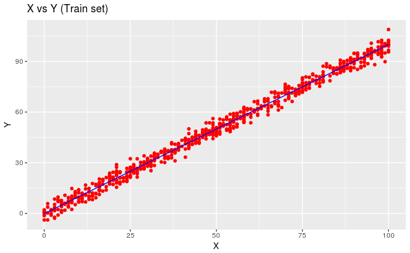

```r
ggplot() +
  geom_point(aes(x = trainSet$x, y = trainSet$y),
             colour = 'red') +
  geom_line(aes(x = trainSet$x, y = predict(reg, newdata = trainSet)),
            colour = 'blue') +
  ggtitle('X vs Y (Train set)') +
  xlab('X') +
  ylab('Y')
```

- Above plot clearly shows that..there is a linear relationship between x and y which is continous in nature.
- So now it’s time to bring Test-data…

```r
# Importing test data
testSet = read.csv('/home/kunal/Documents/DS/Linear-Regression/Data/test.csv')
# Predicting the test results
y_pred = predict(reg, newdata = testSet)
```

#### Now have a look at test data…

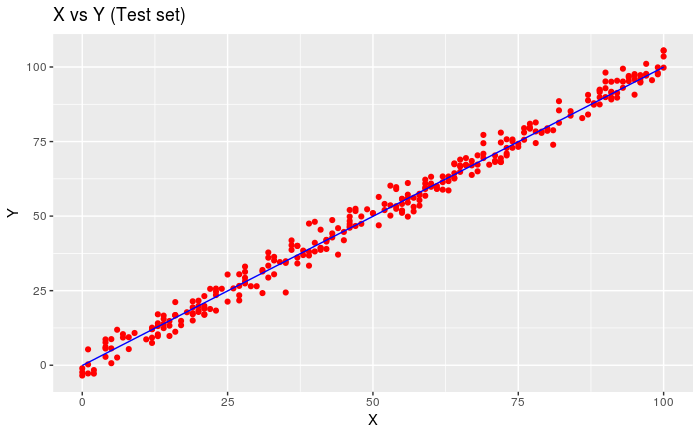

```r
ggplot() +
  geom_point(aes(x = testSet$x, y = testSet$y),
             colour = 'red') +
  geom_line(aes(x = trainSet$x, y = predict(reg, newdata = trainSet)),
            colour = 'blue') +
  ggtitle('X vs Y (Test set)') +
  xlab('X') +
  ylab('Y')
```

```r
compare <- cbind (actual=testSet$x, y_pred)  # combine actual and predicted
mean (apply(compare, 1, min)/apply(compare, 1, max))
```

```
[1] -Inf
```

```r
mean(0.9,0.9,0.9,0.9)
```

```
[1] 0.9
```